# Non-parametrics

April 24, 2018

## Reminders

- What does a t-test do?
- What kinds of t-tests are there?
- What are the assumptions?

## T-test Assumptions

- Variable is continuous
- Random/Independent
- Data is normally distributed
- Sample size?
- Equal variance

## Relaxing the assumptions

- Continuous (not necessarily normal) distribution
  - Can actually use ordinal data
- Random/Independent

## The tests

| parametric | non-parametric |
| --- | --- |
| 1 sample t | sign test or Wilcoxon signed-rank test |
| 2 sample t (not paired) | **Wilcoxon-Mann-Whitney** |
| 2 sample paired t (matched pairs) | reduce to 1 sample |

## Wilcoxon-Mann-Whitney

- Toothpaste data set
- Why not use a t-test?

## Running the test by hand

\(W_1 = n_1 n_2 + \dfrac{n_1(n_1+1)}{2}-R_1\)

\(W_2 = n_1 n_2 + \dfrac{n_2(n_2+1)}{2}-R_2\)

## Toothpaste 1b

Try with the second dataset

## Toothpaste 2

## Making your own dataset

Create a small dataset which has a lot of overlap, compute \(W_1\) and \(W_2\).

Now do the same with a small dataset with no overlap.

What conclusions can you make about possible values of \(W_1\) and \(W_2\)?

## More calculating

What is \(W_1+W_2\) in general? Find a formula.

## Coding this

```r
toothpaste2 %>% wilcox.test(score~brand, data=.)
```

```
##
##  Wilcoxon rank sum test with continuity correction
##
## data:  score by brand
## W = 4.5, p-value = 0.5536
## alternative hypothesis: true location shift is not equal to 0
```

Try 1b and 2

## A Question

Why did I say this would more more related to medians than means?

## Animal data

Download the animal data dataset. This includes information on animals and the length of time they’re in a shelter before being adopted. What kinds of questions could we answer?

Consider some descriptive statistics / graphs.

## Animals

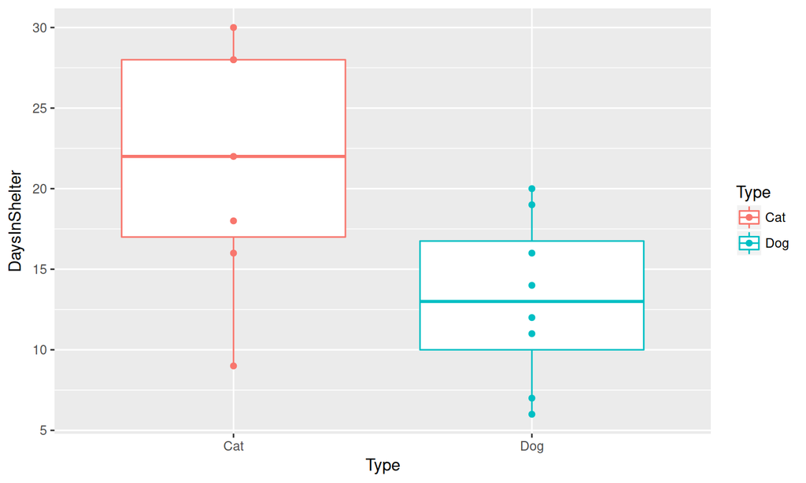

```r
AnimalData %>% ggplot(aes(x=Type, y=DaysInShelter, color=Type)) +
  geom_boxplot() + geom_point()
```

## More plots

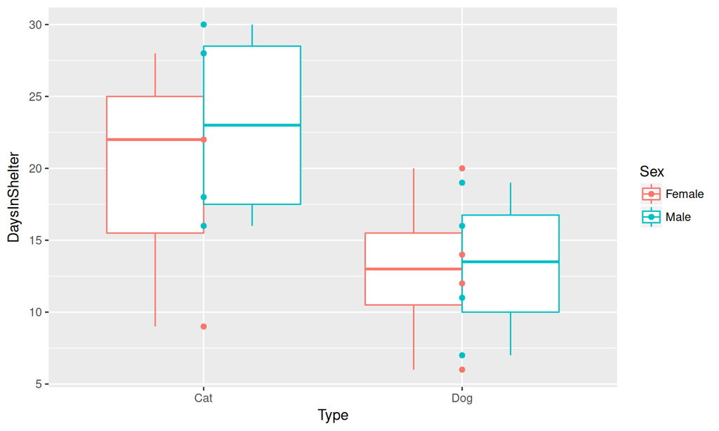

```r
AnimalData %>% ggplot(aes(x=Type, y=DaysInShelter, color=Sex)) +
  geom_boxplot() + geom_point()
```

## A significiant difference?

Is there a statistically significant difference in the length of time before adoption between cats and dogs?

Between male animals and female animals?

## Relationship to t-test

Would the t-test have been a reasonable alternative for the animaldata analysis?

## Null hypothesis

What is the null hypothesis for the Wilcoxon-Mann Whitney test?

- The distribution of group A and group B are the same.
- This is usually interpreted to mean we assume the same shape distribution, and the medians are the same.

## Kruskal–Wallis

## Non-parametric version of an ANOVA

What did an ANOVA do?

## ANOVA assumptions

- Errors have mean 0
- Equal variance
- Normally distributed
- Independent

## Kruskal–Wallis assumptions

- Independence
- Response variable should be at least ordinal
- Samples come from same type of distribution

## Formula

\[H = (N-1)\dfrac{\sum_{i=1}^g n_i (\bar{r}_i-\bar{r})^2}{\sum_{i=1}^g \sum_{j=1}^{n_i} (r_{ij}-\bar{r})^2}\] Where:

- \(n_i\) is the number of observations in group \(i\)
- \(r_{ij}\) is the rank of observation \(j\) in group \(i\)
- \(N\) is the total number of observations
- \(\bar{r}_i\) is the average rank of observations in group \(i\)
- \(\bar{r}\) is the average of all the \(r_{ij}\)

## What does this give us?

(Each of the \(n_i\) should be at least 5 for the approximation to be valid.)

## Some more algebra

What is a formula for \(\bar{r}\)?

## An Example

More toothpaste!

## Running the test

```r
toothpaste4$brand <- as.factor(toothpaste4$brand)
toothpaste4$score <- as.numeric(toothpaste4$score)
toothpaste4 %>% kruskal.test(score~brand, data=.)
```

```
##
##  Kruskal-Wallis rank sum test
##
## data:  score by brand
## Kruskal-Wallis chi-squared = 5.3571, df = 2, p-value = 0.06866
```

- df is the number of groups-1

## Let’s return to the cdc dataset

- What questions could we answer with a Wilcoxon-Mann-Whitney test?
- What questions could we answer with a Kruskal-Wallace test?

Note: try to determine whether there is a difference in ages between genders.